# Exploratory Analysis on Social Vulnerability Measures of Locations of Green Chair Clients

The CDC Social Vulnerability Index (SVI) is a collection of social vulnerability measures for each census tract. We merged the CDC SVIs into the zip codes of the TGCP clients.

## Gathering some initial descriptive statistics on the numerical data

```
##                    vars    n     mean       sd   median  trimmed      mad
## Id                    1 5448 35417.06 10733.98 38435.50 38435.50  2019.30
## Veteran               2 5448     0.06     0.24     0.00     0.00     0.00
## Incarcerated          3 5448     0.03     0.18     0.00     0.00     0.00
## Disability            4 5448     0.05     0.22     0.00     0.00     0.00
## AnnualIncomeAmount    5 3493 13246.58 28104.24 10140.00 11488.37 12898.62
## TotalHHNumber         6 5332     3.10     2.55     3.00     2.82     1.48
## NumAdultFemales       7 3923     1.05     0.76     1.00     1.00     0.00
## NumAdultMales         8 3037     0.79     0.96     1.00     0.70     0.00
## NumChildren           9 3896     2.16     1.49     2.00     2.05     1.48
## QueenBeds            10 1534     0.19     0.40     0.00     0.10     0.00
## Cribs                11 1535     0.24     0.47     0.00     0.16     0.00
## TwinBeds             12 2326     1.07     1.32     1.00     0.86     1.48
## AREA_SQMI            13 4793     5.87    11.99     4.57     4.30     2.75
## EP_POV               14 4793    16.68     7.21    16.27    16.60     8.43
## EP_UNEMP             15 4793     5.72     2.08     5.12     5.57     1.78
## EP_PCI               16 4793 30847.33  9701.99 27931.25 29386.65  8080.87
## EP_NOHSDP            17 4793    11.87     4.94    11.83    12.09     6.68
## EP_AGE65             18 4793    10.45     2.97     9.24    10.06     1.33
## EP_AGE17             19 4793    23.15     4.70    23.70    23.63     5.23
## EP_DISABL            20 4793    10.34     2.58    10.35    10.38     3.65
## EP_SNGPNT            21 4793    11.60     4.15    11.77    11.69     5.86
## EP_MINRTY            22 4793    53.96    21.21    60.77    54.59    30.64
## EP_LIMENG            23 4793     3.54     1.97     3.52     3.42     2.04
## EP_MUNIT             24 4793    15.07     8.99    12.13    14.46     7.42
## EP_MOBILE            25 4793     4.54     4.21     4.30     3.89     3.14
## EP_CROWD             26 4793     3.21     1.43     2.85     3.27     1.64
## EP_NOVEH             27 4793     7.02     4.59     6.41     6.27     4.04
## EP_GROUPQ            28 4793     4.24     6.30     2.44     2.70     2.51
## EP_UNINSUR           29 4793    12.85     4.16    14.00    13.20     4.00
## totalBedNeeded       30 5448     0.31     0.85     0.00     0.06     0.00
##                         min        max      range  skew kurtosis     se
## Id                   509.00   41360.00   40851.00 -2.86     6.39 145.43
## Veteran                0.00       1.00       1.00  3.72    11.87   0.00
## Incarcerated           0.00       1.00       1.00  5.07    23.70   0.00
## Disability             0.00       1.00       1.00  4.17    15.37   0.00
## AnnualIncomeAmount     0.00 1500000.00 1500000.00 42.83  2242.63 475.52
## TotalHHNumber          0.00      60.00      60.00 10.84   231.77   0.03
## NumAdultFemales        0.00      10.00      10.00  5.30    48.39   0.01
## NumAdultMales          0.00      17.00      17.00  5.51    55.19   0.02
## NumChildren            0.00      12.00      12.00  0.96     1.78   0.02
## QueenBeds              0.00       3.00       3.00  1.97     3.25   0.01
## Cribs                  0.00       2.00       2.00  1.71     2.00   0.01
## TwinBeds               0.00       7.00       7.00  1.17     0.82   0.03
## AREA_SQMI              0.62     612.33     611.72 30.23  1405.53   0.17
## EP_POV                 2.88      34.33      31.45  0.12    -0.66   0.10
## EP_UNEMP               1.43      15.75      14.32  0.77     0.17   0.03
## EP_PCI             10868.37   73055.91   62187.54  1.31     1.72 140.14
## EP_NOHSDP              1.26      33.04      31.79 -0.14    -0.80   0.07
## EP_AGE65               6.34      34.54      28.19  1.30     2.05   0.04
## EP_AGE17               8.50      31.73      23.23 -0.72    -0.33   0.07
## EP_DISABL              4.94      28.30      23.37  0.24     1.03   0.04
## EP_SNGPNT              3.07      21.93      18.86  0.07    -1.23   0.06
## EP_MINRTY              4.08      81.43      77.36 -0.07    -1.37   0.31
## EP_LIMENG              0.10       9.32       9.22  0.53     0.27   0.03
## EP_MUNIT               0.00      49.20      49.20  0.87     0.73   0.13
## EP_MOBILE              0.14      46.79      46.65  3.02    15.85   0.06
## EP_CROWD               0.00       6.11       6.11 -0.09    -1.26   0.02
## EP_NOVEH               1.10      22.54      21.44  1.69     2.93   0.07
## EP_GROUPQ              0.00      59.45      59.45  2.74     7.77   0.09
## EP_UNINSUR             2.64      21.45      18.81 -0.52    -0.86   0.06
## totalBedNeeded         0.00       6.00       6.00  3.11     9.90   0.01
```

Some things worth noting about SVI statistics of where clients live:

- Percent Poverty averages about 17%, but Percent Unemployment averages only about 5-6%
- About 12% have no high school diploma
- About 12% are single parents
- About 10% have a disability
- Average percent minority is over half
- About a 23% are seventeen or younger
- On average, about 15% live in housing structures with more than 10 units per structure
- About 7% do not have a vehicle
- About 13% do not possess insurance

Some things worth noting about clients:

- Annual Income is right skewed; most annual incomes are small with a few large outliers

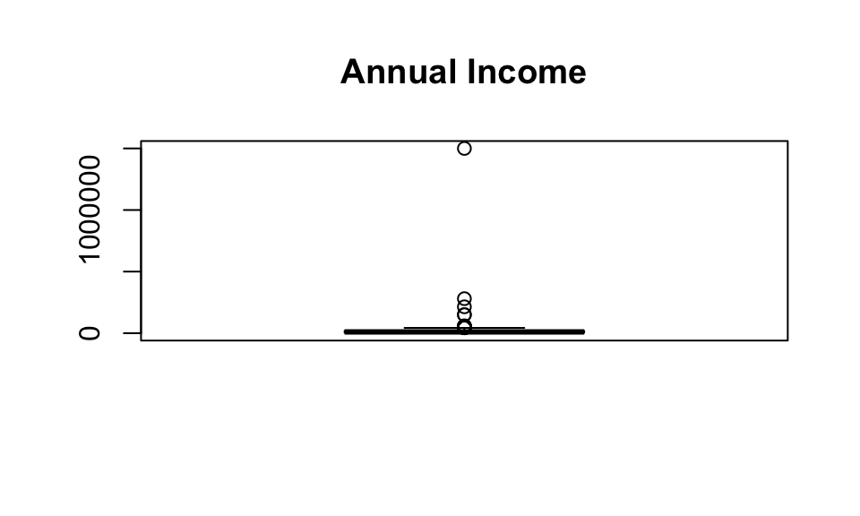

```r
boxplot(numer_GCSVI$AnnualIncomeAmount, main = "Annual Income")
```

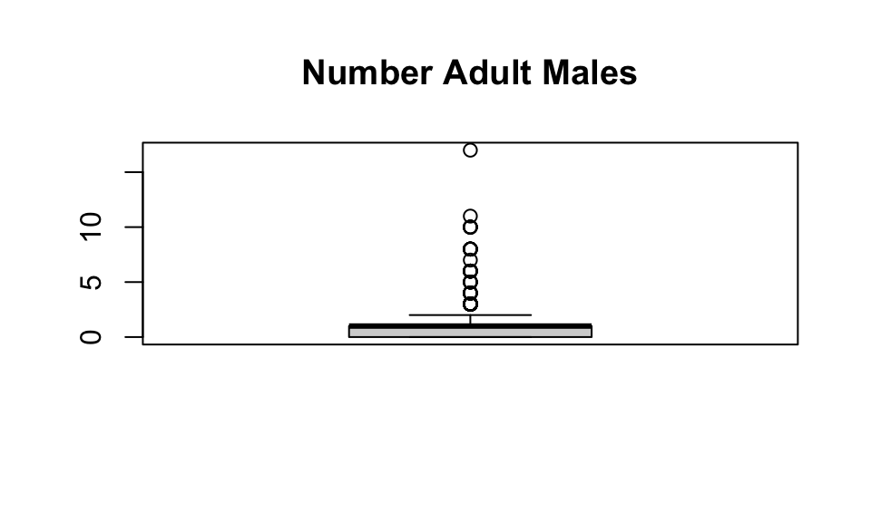

```r
boxplot(numer_GCSVI$NumAdultMales, main = "Number Adult Males")
```

## Some correlation statistics:

- NumChildren negatively correlated with SVI measures of poverty, living in apartment-like structures, and not having a vehicle

  Correlations with NumChildren

```r
numer_cor[row.names(numer_cor) == "NumChildren",]
```

```
##                 Id            Veteran       Incarcerated         Disability
##        0.088100978       -0.120384533       -0.194359942       -0.402893253
## AnnualIncomeAmount      TotalHHNumber    NumAdultFemales      NumAdultMales
##        0.087791712        0.941992816        0.381053590       -0.171283519
##        NumChildren          QueenBeds              Cribs           TwinBeds
##        1.000000000       -0.342336131        0.346127362        0.675141095
##          AREA_SQMI             EP_POV           EP_UNEMP             EP_PCI
##        0.162085383       -0.155583619        0.017041767       -0.027899576
##          EP_NOHSDP           EP_AGE65           EP_AGE17          EP_DISABL
##       -0.001103489        0.080111985        0.194707874        0.097252026
##          EP_SNGPNT          EP_MINRTY          EP_LIMENG           EP_MUNIT
##        0.044247983        0.003053117       -0.071385536       -0.226939703
##          EP_MOBILE           EP_CROWD           EP_NOVEH          EP_GROUPQ
##        0.179560159       -0.032375529       -0.158472473       -0.119809180
##         EP_UNINSUR     totalBedNeeded
##       -0.022357626        0.532777889
```

- We see that a need for queen beds is positively correlated with those incarcerated and especially those with a disability. Need for queen beds is also slightly positively correlated with SVI measures of poverty and not having a vehicle

  Correlations with QueenBeds

```r
numer_cor[row.names(numer_cor) == "QueenBeds",]
```

```
##                 Id            Veteran       Incarcerated         Disability
##       -0.041088404        0.065833132        0.125049115        0.318662827
## AnnualIncomeAmount      TotalHHNumber    NumAdultFemales      NumAdultMales
##       -0.123166197       -0.349047273       -0.259406932        0.141297825
##        NumChildren          QueenBeds              Cribs           TwinBeds
##       -0.342336131        1.000000000       -0.184143488       -0.243592911
##          AREA_SQMI             EP_POV           EP_UNEMP             EP_PCI
##       -0.062729793        0.156332307        0.028647202       -0.078647594
##          EP_NOHSDP           EP_AGE65           EP_AGE17          EP_DISABL
##        0.062296986       -0.103019846       -0.093494622       -0.005538143
##          EP_SNGPNT          EP_MINRTY          EP_LIMENG           EP_MUNIT
##        0.014202936        0.050345741        0.086509129        0.080775081
##          EP_MOBILE           EP_CROWD           EP_NOVEH          EP_GROUPQ
##       -0.051837563        0.088620027        0.096149706        0.058209794
##         EP_UNINSUR     totalBedNeeded
##        0.060873471       -0.198013697
```

- Need for twin beds is slightly positively correlated with SVI measures of percent of population aged less than or equal to 17, and percent of population living in mobile homes (in fact, the need for beds in general is correlated with these SVI measures)

  Correlations with TwinBeds

```r
numer_cor[row.names(numer_cor) == "TwinBeds",]
```

```
##                 Id            Veteran       Incarcerated         Disability
##        0.051602714       -0.094427391       -0.114955764       -0.289451406
## AnnualIncomeAmount      TotalHHNumber    NumAdultFemales      NumAdultMales
##        0.196108599        0.664869170        0.307454925       -0.147670269
##        NumChildren          QueenBeds              Cribs           TwinBeds
##        0.675141095       -0.243592911       -0.013705872        1.000000000
##          AREA_SQMI             EP_POV           EP_UNEMP             EP_PCI
##        0.172649764       -0.106965549        0.040593093       -0.029623810
##          EP_NOHSDP           EP_AGE65           EP_AGE17          EP_DISABL
##        0.005692942        0.052686064        0.162381056        0.093537920
##          EP_SNGPNT          EP_MINRTY          EP_LIMENG           EP_MUNIT
##        0.041055912        0.010695178       -0.071210977       -0.183301980
##          EP_MOBILE           EP_CROWD           EP_NOVEH          EP_GROUPQ
##        0.149448032       -0.006169949       -0.105790148       -0.084840753
##         EP_UNINSUR     totalBedNeeded
##       -0.021351609        0.655735893
```

- We see some of the largest correlation values with Disability, i.e.
  - SVI measures of poverty, no high school diploma, speaking English “less than well”, living in apartment-like structures and crowded environments, having no vehicle, and not being insured

However, it is worth noting that SVI statistics may look at a population different from that of TGCP clients. For instance, the correlation between those with a disability among the clients in the original dataset and the percent of population in the client’s zipcode with a disability is quite small.

```
Correlations with Disability
```

```r
numer_cor[row.names(numer_cor) == "Disability", ]
```

```
##                 Id            Veteran       Incarcerated         Disability
##        -0.09857245         0.15752888         0.22783623         1.00000000
## AnnualIncomeAmount      TotalHHNumber    NumAdultFemales      NumAdultMales
##        -0.08877691        -0.40423868        -0.33484527         0.19405214
##        NumChildren          QueenBeds              Cribs           TwinBeds
##        -0.40289325         0.31866283        -0.23848150        -0.28945141
##          AREA_SQMI             EP_POV           EP_UNEMP             EP_PCI
##        -0.07673890         0.18183079         0.05490866        -0.05674462
##          EP_NOHSDP           EP_AGE65           EP_AGE17          EP_DISABL
##         0.09120429        -0.08282131        -0.11663996        -0.00640091
##          EP_SNGPNT          EP_MINRTY          EP_LIMENG           EP_MUNIT
##         0.02323929         0.06097843         0.14217491         0.12372275
##          EP_MOBILE           EP_CROWD           EP_NOVEH          EP_GROUPQ
##        -0.09265279         0.07883842         0.17671029         0.11517297
##         EP_UNINSUR     totalBedNeeded
##         0.07972229        -0.23457432
```

## Deeper Dive Into Correlated Relationships

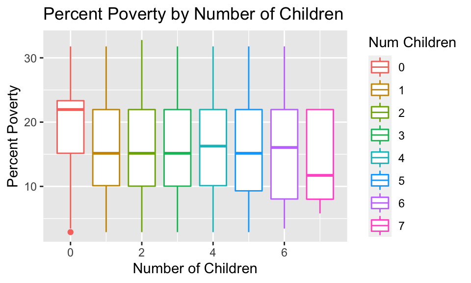

Some things to note:

- We see that the distribution among number of children is about the same
- Those with no children, however, often are within more impoverished areas

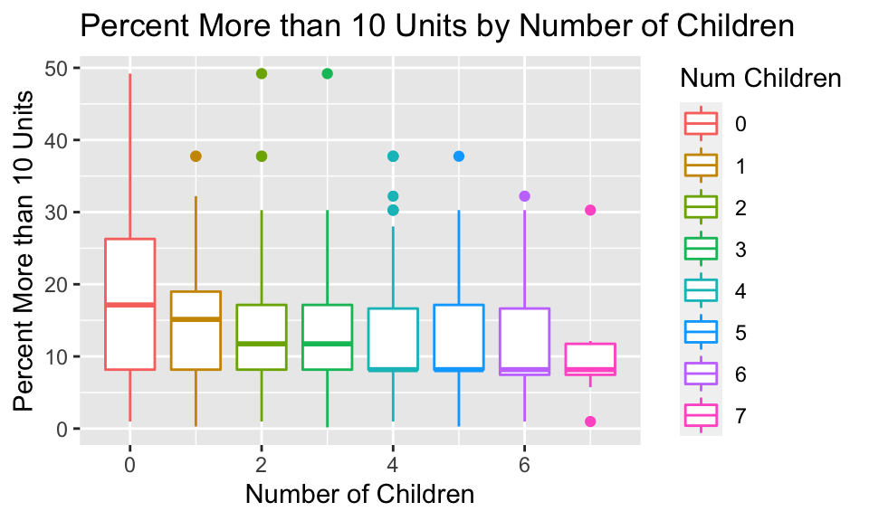

Some things to note:

- We see that the distribution among number of children varies; in general we see that having more children is associated with a smaller probability of living in a structure with more than ten housing units

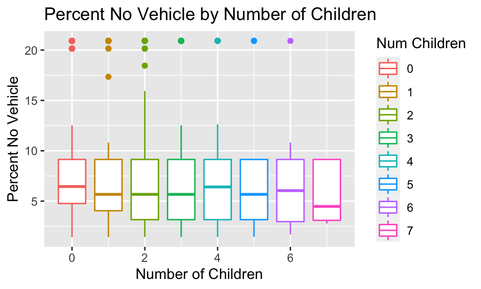

Some things to note:

- We see that the distribution among number of children is about the same
  - There are a few clients that live in areas where the probability of having no vehicle is high no matter the number of children (there are several high outliers)

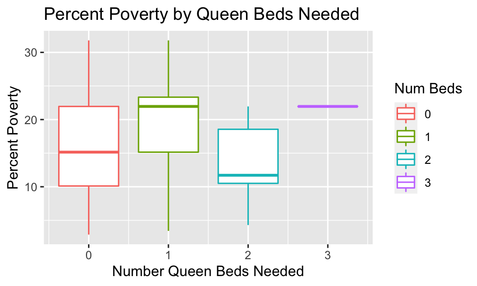

Some things to note:

- We see that that distribution among number of queen beds varies. It is worth noting that:
  - Those that need one queen bed tend to live in more impoverished areas
  - It would be worth looking into how the need for a queen bed is distributed among those with a disability

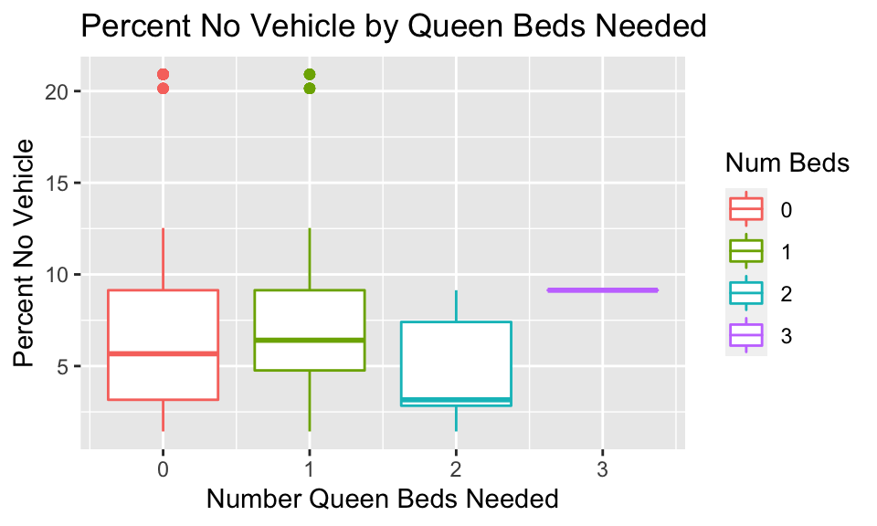

Some things to note:

- We see that that distribution among number of queen beds varies.

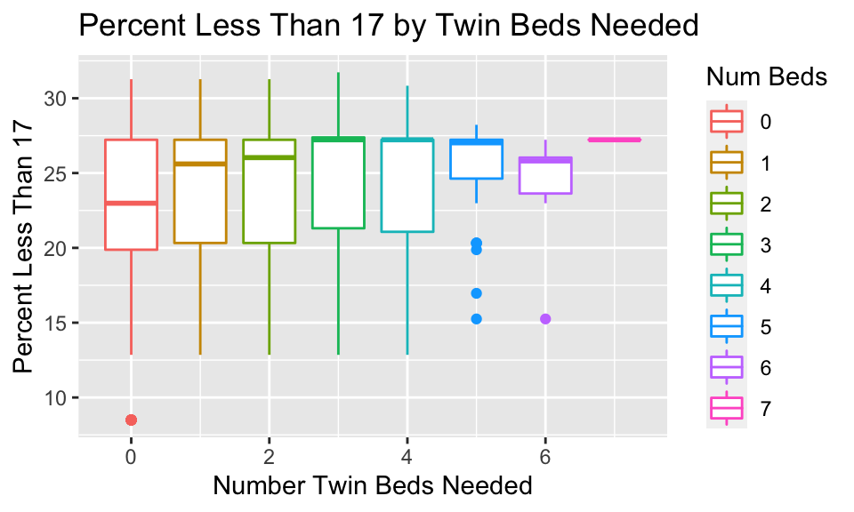

Some things to note:

- We see that that distribution among number of twin beds varies. It is worth noting that overall, however, that the need for twin beds increases as one tends to live in areas with more people less than 17 years of age.